# Assess population structure

Lorenzo Bertola

Document last run on 2024-07-01

## 0. Background

I have now obtained a set of called genotypes for all individuals I plan to use for analyses of sex-determination. These individuals come from three lineages which meet at two contact zones. Some of these, from 2022, have never been analysed before and might contain mis-identified individuals and/or hybrids. I need to identify such individuals and remove them or assign them to the correct lineage. Additionally, I want to assess population structure so that I can designate population strata for analyses of sex-determination accordingly.

## 0. Packages and data

Load packages

```r
library(dartR)
library(adegenet)
library(vcfR)
library(tidyverse)
library(ggpubr)
library(see)
```

Convert to genlight format

```r
my.gl <- gl.read.vcf("../2_PopStructure/2_3_filtered_All.recode.vcf")
```

[output not shown]

## 1. Filter by missingness

Filter by missingness (i.e., call rate)

```r
my.gl <- gl.filter.callrate(my.gl, method = "loc", threshold = 0.9)
```

```
## Starting gl.filter.callrate
##   Processing genlight object with SNP data
##   Recalculating Call Rate
##   Removing loci based on Call Rate, threshold = 0.9
```

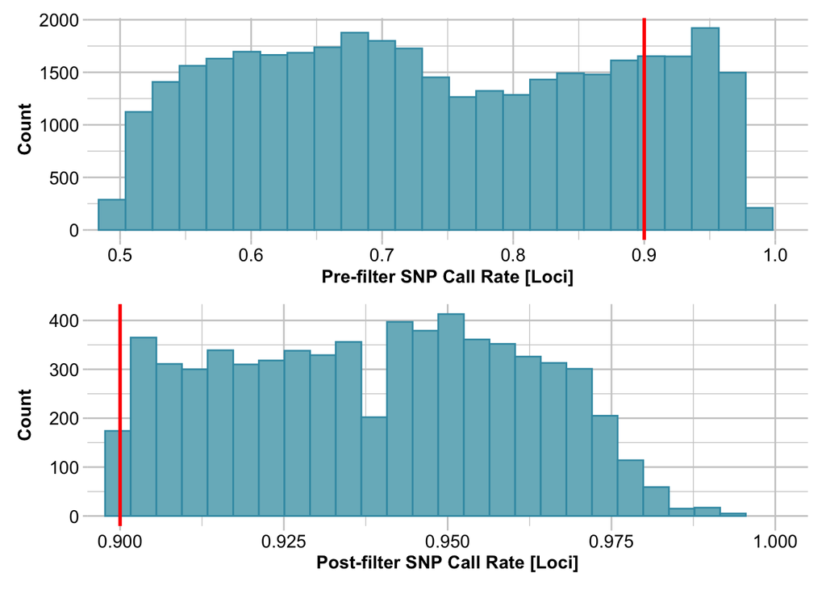

```
## Completed: gl.filter.callrate
```

Assign population IDs (contained in the sample names)

```r
pops <- substr(my.gl@ind.names,1,4)

pop(my.gl) <- pops
```

Alternatively, assign correct pop ids based on later analyses (next PhD chapter)

```r
my.df <- read_csv("../0_metadata/popIds.csv")
pop(my.gl) <- my.df$lin2
```

## 2. PCOA all

```r
my.pcoa <- gl.pcoa(my.gl)
```

```
## Starting gl.pcoa
##   Processing genlight object with SNP data
##   Performing a PCA, individuals as entities, loci as attributes, SNP genotype as state
```

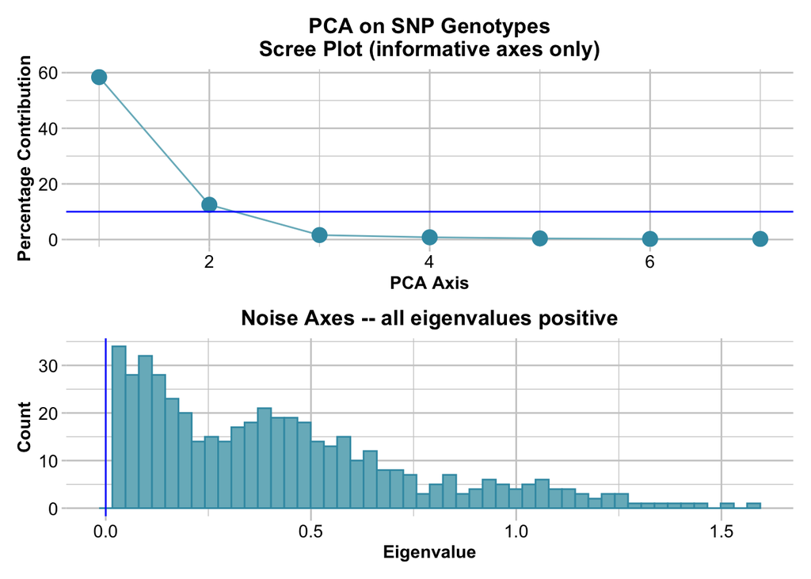

```
## Completed: gl.pcoa
```

Plot the results

```
## Starting gl.pcoa.plot
##   Processing an ordination file (glPca)
##   Processing genlight object with SNP data
##   Plotting populations in a space defined by the SNPs
##   Preparing plot .... please wait
```

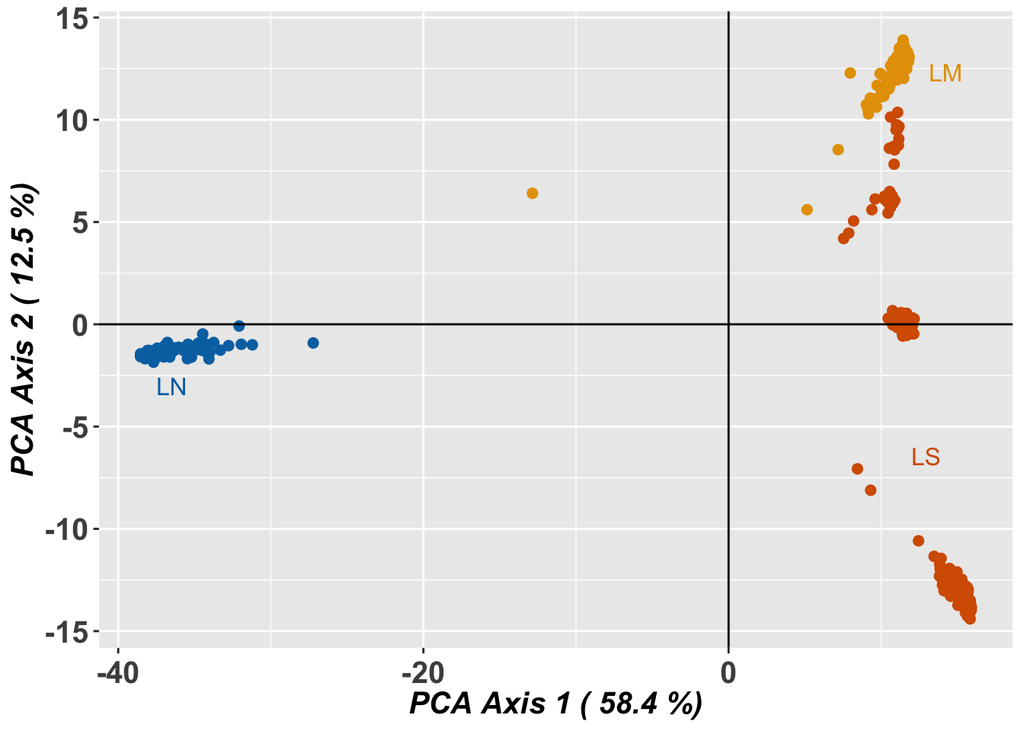

```
## Completed: gl.pcoa.plot
```

```r
p1 <- gl.pcoa.plot(my.pcoa,my.gl,interactive = FALSE,
             pop.labels = 'pop',
             pt.colors = c("#E69F00","#0072B2","#D55E00"))
```

```r
p1
```

```
## Starting gl.pcoa.plot
##   Processing an ordination file (glPca)
##   Processing genlight object with SNP data
##   Plotting populations in a space defined by the SNPs
##   Preparing plot .... please wait
```

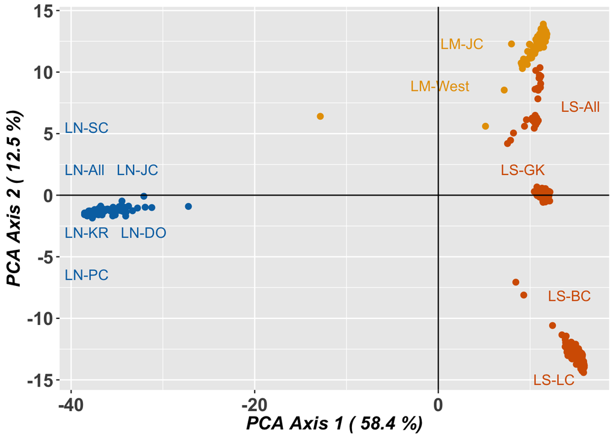

```
## Completed: gl.pcoa.plot
```

```r
my.gl2 <- my.gl
pop(my.gl2) <- my.df$Pop4

 p2 <- gl.pcoa.plot(my.pcoa,my.gl2,interactive = FALSE,
             pop.labels = 'pop',
             pt.colors = c("#E69F00","#E69F00",
                           "#0072B2","#0072B2","#0072B2",
                           "#0072B2","#0072B2","#0072B2",
                           "#D55E00","#D55E00",
                           "#D55E00","#D55E00"))
```

```r
p2
```

We can see that some of the samples that were IDentified as L. myola in the field (salmon colour) are actually from the northern lineage. Further, there is one F1 hybrid and 1 possible backcross hybrid. We are going to remove the hybrids, re-assign the LM samples to LN that belong to that lineage, and run gstacks separately on each lineage.

```r
my.df <- as.data.frame(my.pcoa$scores)

my.df <- tibble::rownames_to_column(my.df, var = "IndName")
```

## 3. Re-assign population and remove hybrids

Now we will filter samples with a score between -30 and 0 on Axis 1 to remove the hybrids.

```r
my.df <- my.df %>%
  filter(PC1 < -30 | PC1 > 0)
```

We will also filter the linkage mapping parents which have more than twice the coverage (they were filter at higher read depth) and often pop out as somewhat distinct (these are identified in the above plot with "Female" and "Male" in their name).

```r
my.df <- my.df %>%
  filter(!str_detect(IndName, 'Female|Male'))
```

Now we are going to create one pop file per lineage

```r
LN <- my.df %>%
  filter(PC1 < -30) %>%
  select(IndName) %>%
  add_column(Pop = "LN")

LM <- my.df %>%
  filter(PC1 > 0) %>%
  filter(str_detect(IndName, "LM_M")) %>%
  select(IndName) %>%
  add_column(Pop = "LM")

LS <- my.df %>%
  filter(PC1 > 0) %>%
  filter(str_detect(IndName, "LS_S")) %>%
  select(IndName) %>%
  add_column(Pop = "LS")
```

Let's save them as tab delimited files to be used for gstacks

```r
write_delim(LS,
            file = "../2_PopStructure/2_popfile_LS",
            delim = "\t",
            col_names = FALSE)

write_delim(LN,
            file = "../2_PopStructure/2_popfile_LN",
            delim = "\t",
            col_names = FALSE)

write_delim(LM,
            file = "../2_PopStructure/2_popfile_LM",
            delim = "\t",
            col_names = FALSE)
```

Let's now run a pcoa for each lineage to assess how to subset populations for sex-linkage and gwas analyses. First we adjust the population assignment based on the previous pcoa plots

```r
#make dataframe of individual names
my.names <- as.data.frame(my.gl@ind.names)
#name column to match the LM, LN, LS dataframes
colnames(my.names) <- "IndName"

#bind LM LN and LS
my.pops <- rbind(LM,LN,LS)

#join the ind names and the my.pops to add the adjusted population info
my.pops <- left_join(my.names,my.pops)
#change NA values to "NA"
my.pops <- my.pops %>% mutate(Pop = replace_na(Pop, "NA"))

#add "NA" to levels of populations to allow for hybrid individuals to have no population assigned, as we will exclude these
levels(my.gl@pop) <- c("LM","LN","LS","NA")

#set the new population
my.gl$pop <- as.factor(my.pops$Pop)

#clear environment
rm(my.pops,my.names)
```

## 4. PCOA by lineage

Then we subset into three separate gl files, one per lineage

```r
my.LS <- my.gl[pop="LS"]
my.LN <- my.gl[pop="LN"]
my.LM <- my.gl[pop="LM"]
```

Now let's run the pcoas.

```r
my.pcoa.LS <- gl.pcoa(my.LS)
```

```
## Starting gl.pcoa
##   Processing genlight object with SNP data
##   Performing a PCA, individuals as entities, loci as attributes, SNP genotype as state
```

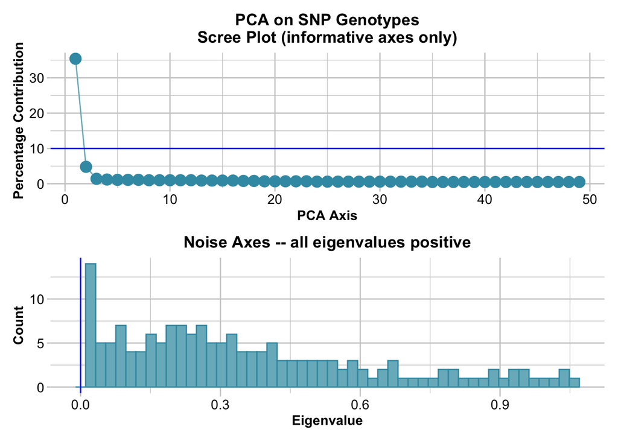

```
## Completed: gl.pcoa
```

```r
my.pcoa.LN <- gl.pcoa(my.LN)
```

```
## Starting gl.pcoa
##   Processing genlight object with SNP data
##   Performing a PCA, individuals as entities, loci as attributes, SNP genotype as state
```

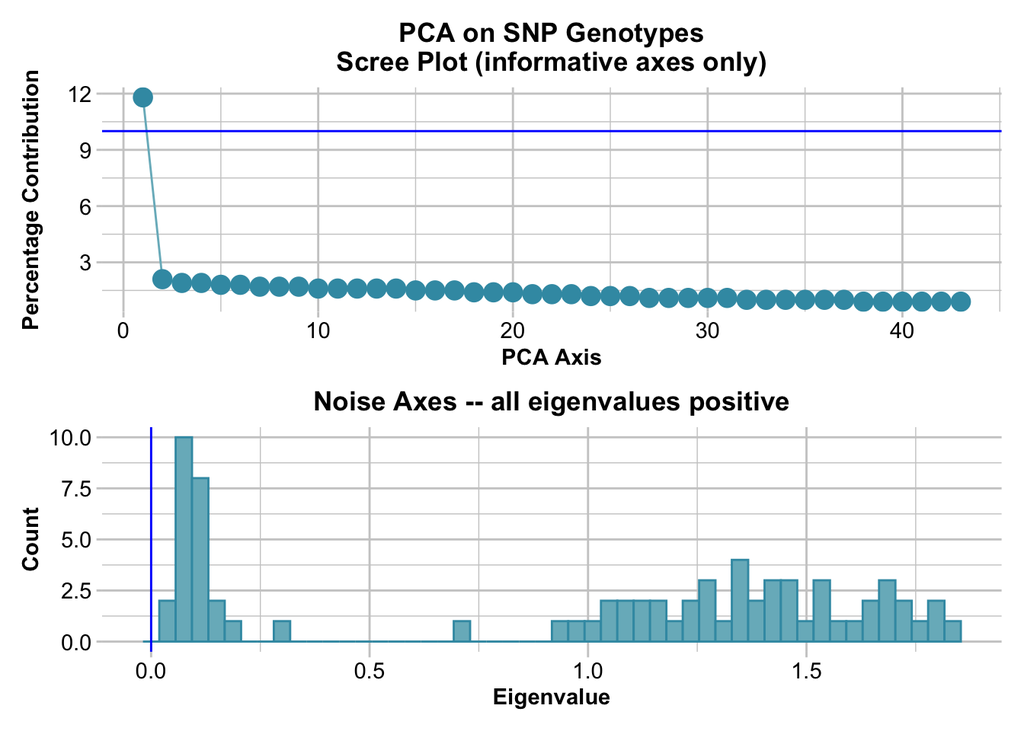

```
## Completed: gl.pcoa
```

```r
my.pcoa.LM <- gl.pcoa(my.LM)
```

```
## Starting gl.pcoa
##   Processing genlight object with SNP data
##   Performing a PCA, individuals as entities, loci as attributes, SNP genotype as state
```

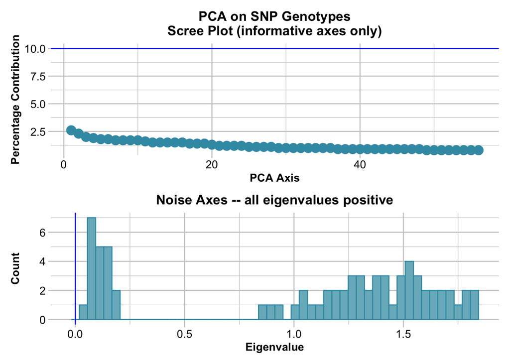

```
## Completed: gl.pcoa
```

Extract pcoa scores and format

```r
my.pop.df <- read_csv("../0_metadata/popIds.csv")
my.pcoa.LS.2 <- as_tibble(my.pcoa.LS$scores,rownames=NA) %>%
  rownames_to_column("indName") %>%
  mutate(indName = gsub(".sort","",indName))
my.pcoa.LN.2 <- as_tibble(my.pcoa.LN$scores,rownames=NA) %>%
  rownames_to_column("indName") %>%
  mutate(indName = gsub(".sort","",indName))
my.pcoa.LM.2 <- as_tibble(my.pcoa.LM$scores,rownames=NA) %>%
  rownames_to_column("indName") %>%
  mutate(indName = gsub(".sort","",indName))
```

```r
my.pcoa.LS.2 <- left_join(my.pcoa.LS.2,my.pop.df)
my.pcoa.LN.2 <- left_join(my.pcoa.LN.2,my.pop.df)
my.pcoa.LM.2 <- left_join(my.pcoa.LM.2,my.pop.df)
```

Plot results colouring by sampling site

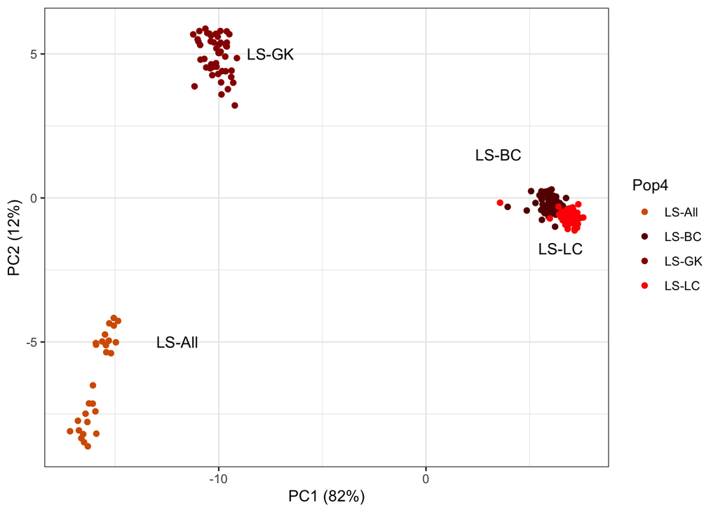

```r
p1 <- ggplot(my.pcoa.LS.2) +
  geom_point(aes(x=PC1,y=PC2,fill=Pop4,colour=Pop4)) +
  scale_color_manual(values = c("#D55E00","#660000","#990000","#FF0000")) +
  annotate(x = -12, y = -5,geom = "text", label="LS-All") +
  annotate(x = -7.5, y = 5,geom = "text", label="LS-GK") +
  annotate(x = 3.5, y = 1.5,geom = "text", label="LS-BC") +
  annotate(x = 6.5, y = -1.75,geom = "text", label="LS-LC") +
  xlab("PC1 (82%)") +
  ylab("PC2 (12%)") +
  theme_bw()
p1
```

```r
ggsave("../2_PopStructure/2_1_glPCOA_LS.png",p1, device = "png",dpi=300)
```

Litoria serrata southern lineage (LS) shows 3-4 clusters. At the top we have YC, MR and DG samples (all from the Girramay-Kirrama region), on the bottom left we have two clusters, the top one with samples from Mungalli falls (MF) and Goolagan Creek (GC), and the bottom one with samples from Davies Creek (DV) and the 07 and 08 transects. On the right finally we have all the samples ffrom the southern end of the range, including No name creek 1 and 2 (N1, N2), Little Crystal Creek (LC), Ethel Creek (EC), Birthday Creek (BC) and Cloudy Creek (CL). These match what we knew about the species, and is well described in McKnight et al. (2019), who provided most of these samples.

```r
gl.pcoa.plot(my.pcoa.LS,my.LS, interactive = TRUE)
```

```
## Starting gl.pcoa.plot
##   Processing an ordination file (glPca)
##   Processing genlight object with SNP data
##   Plotting populations in a space defined by the SNPs
##   Displaying an interactive plot
##   NOTE: Returning the ordination scores, not a ggplot2 compatable object
##   Ignore any warning on the number of shape categories
##   Preparing plot .... please wait
## Completed: gl.pcoa.plot
```

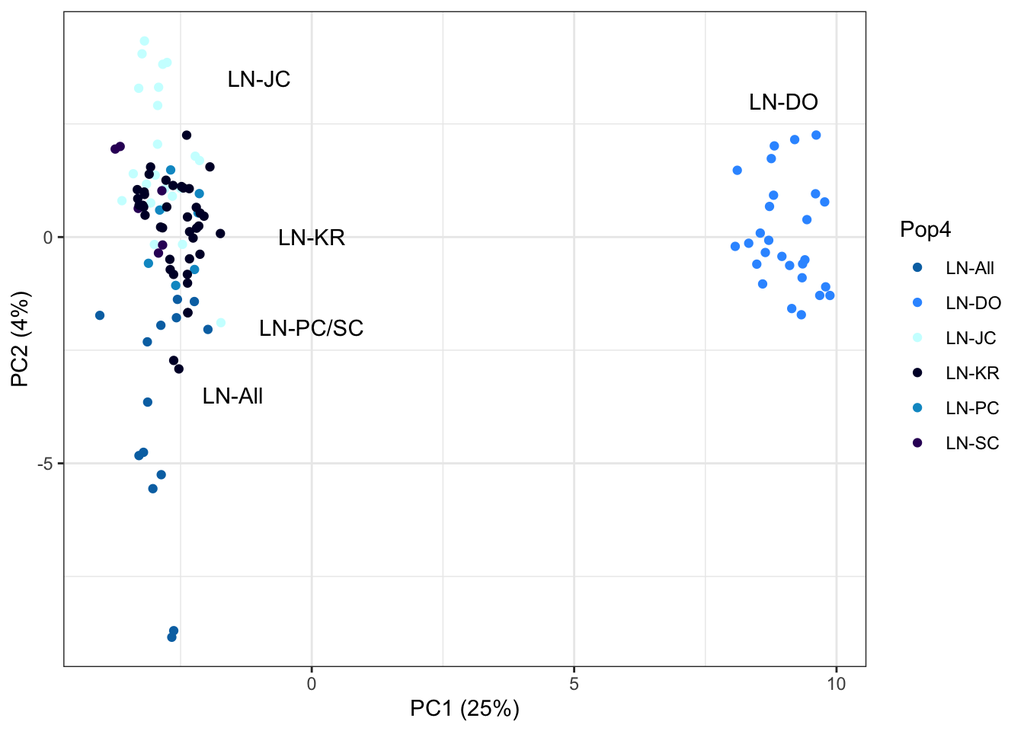

```r
p2 <- ggplot(my.pcoa.LN.2) +
  geom_point(aes(x=PC1,y=PC2,fill=Pop4,colour=Pop4)) +
  scale_color_manual(values = c("#0072B2","#3399FF","#CCFFFF",
                                "#000033","#0099CC","#330066")) +
  annotate(x = 9, y = 3,geom = "text", label="LN-DO") +
  annotate(x = -1, y = 3.5,geom = "text", label="LN-JC") +
  annotate(x = 0, y = 0,geom = "text", label="LN-KR") +
  annotate(x = -1.5, y = -3.5,geom = "text", label="LN-All") +
  annotate(x = 0, y = -2,geom = "text", label="LN-PC/SC") +
  xlab("PC1 (25%)") +
  ylab("PC2 (4%)") +
  theme_bw()
p2
```

```r
ggsave("../2_PopStructure/2_1_glPCOA_LN.png", p2,
       device = "png", dpi = 300)
```

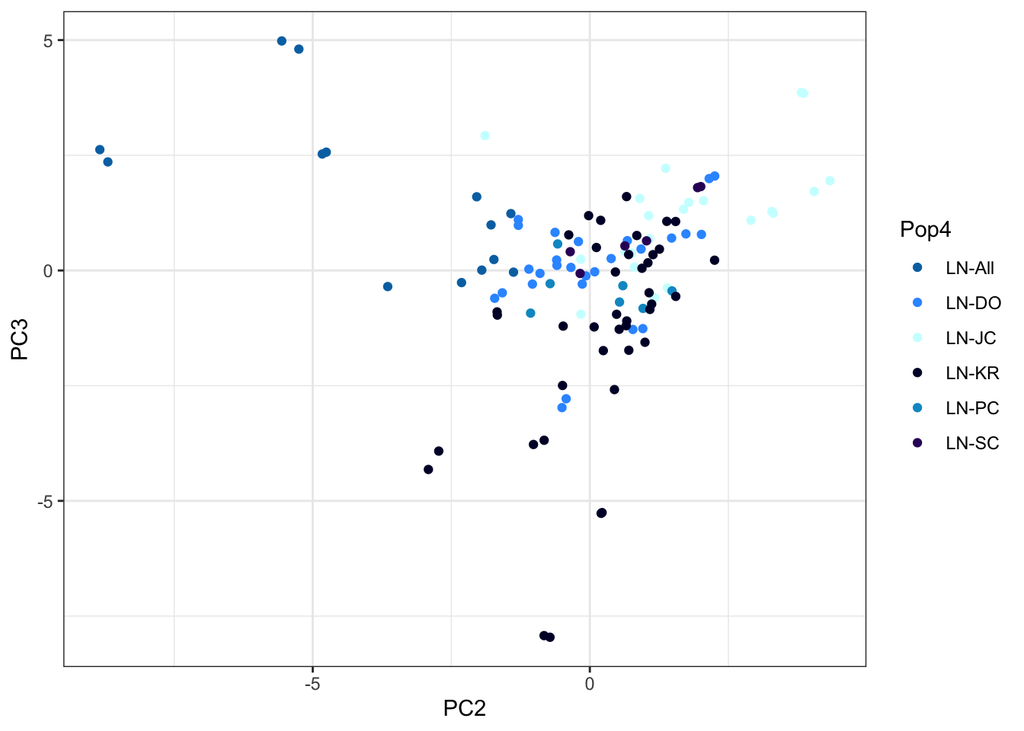

```r
p2b <- ggplot(my.pcoa.LN.2) +
  geom_point(aes(x=PC2,y=PC3,fill=Pop4,colour=Pop4)) +
  scale_color_manual(values = c("#0072B2","#3399FF","#CCFFFF",
                                "#000033","#0099CC","#330066")) +
  #annotate(x = -12, y = -5,geom = "text", label="LS-All") +
  #annotate(x = -7.5, y = 5,geom = "text", label="LS-GK") +
  #annotate(x = 3.5, y = 1.5,geom = "text", label="LS-BC") +
  #annotate(x = 6.5, y = -1.75,geom = "text", label="LS-LC") +
  theme_bw()
p2b
```

Litoria serrata northern lineage shows two main clusters at this resolution, with samples north of the Daintree river (DO) being separated by the rest of the species. The left cluster on the other hand shows a north south trend, with the 07 and 08 transects being at the south edge of the species distribution, while the remaining samples are all found nearby the Kuranda region. Interestingly, there is temporal resolution as well, with the samples from the early 2000s (JC) appearing at the top, while the remaining samples collected between 2015 and 2022 sit in the middle.

```r
gl.pcoa.plot(my.pcoa.LN,my.LN, interactive = TRUE)
```

```
## Starting gl.pcoa.plot
##   Processing an ordination file (glPca)
##   Processing genlight object with SNP data
##   Plotting populations in a space defined by the SNPs
##   Displaying an interactive plot
##   NOTE: Returning the ordination scores, not a ggplot2 compatable object
##   Ignore any warning on the number of shape categories
##   Preparing plot .... please wait
## Completed: gl.pcoa.plot
```

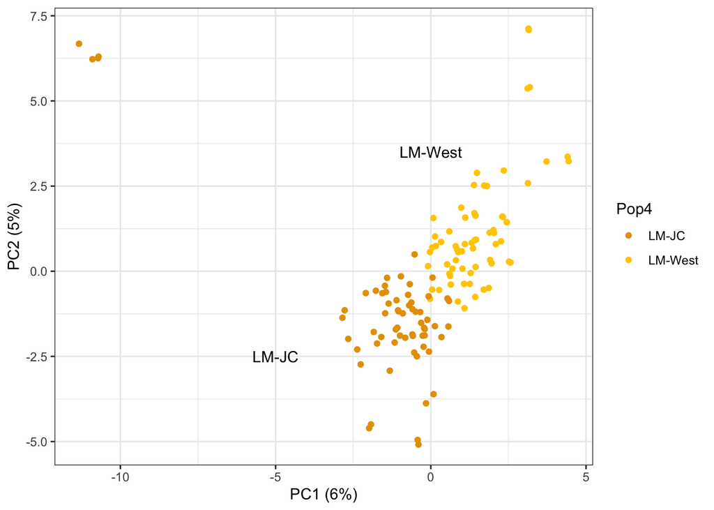

```r
p3 <- ggplot(my.pcoa.LM.2) +
  geom_point(aes(x=PC1,y=PC2,fill=Pop4,colour=Pop4)) +
  scale_color_manual(values = c("#E69F00","#FFCC00")) +
  annotate(x = 0, y = 3.5, geom = "text", label="LM-West") +
  annotate(x = -5, y = -2.5,geom = "text", label="LM-JC") +
  xlab("PC1 (6%)") +
  ylab("PC2 (5%)") +
  theme_bw()
p3
```

```r
ggsave("../2_PopStructure/2_1_glPCOA_LM.png", p3,
       device = "png", dpi = 300)
```

```r
gl.pcoa.plot(my.pcoa.LM,my.LM, interactive = TRUE)
```

```
## Starting gl.pcoa.plot
##   Processing an ordination file (glPca)
##   Processing genlight object with SNP data
##   Plotting populations in a space defined by the SNPs
##   Displaying an interactive plot
##   NOTE: Returning the ordination scores, not a ggplot2 compatable object
##   Ignore any warning on the number of shape categories
##   Preparing plot .... please wait
## Completed: gl.pcoa.plot
```

The two samples on the top left are LM_M_JC_Kindie5 and LM_M_JC_lowerKindie1.

```r
p4 <- ggarrange(p2,p3,p1,ncol = 1,align = "v")
```

```r
ggsave("../2_PopStructure/2_1_glPCOA_ALL.png", p4,
       device = "png", dpi = 300, height = 10, width = 7)
```

## Genetic diversity by population

Extract individual names

```r
my.names <- tibble("indName" = gsub(".sort","",indNames(my.gl)),
                   "lin" = pop(my.gl))
```

Add sampling locality ID, make unique lineage + locality identifier, then case when to group localities into populations

```r
my.df <- read_csv("../0_metadata/popIds.csv")
my.names <- left_join(my.names,my.df, by = c("indName"))
```

```r
pop(my.gl) <- my.names %>% pull(Pop5)
```

Keep only population level (drop small number of individuals that were included only as LN-All, LM-All and LS-All)

```r
my.gl <- gl.drop.pop(my.gl, pop.list = c("LN-All","LM-All","LS-All"))
```

```
## Starting gl.drop.pop
##   Processing genlight object with SNP data
##   Checking for presence of nominated populations, deleting them
##   Warning: Resultant dataset may contain monomorphic loci
##   Locus metrics not recalculated
## Completed: gl.drop.pop
```

```r
my.gl.het <- gl.report.heterozygosity(my.gl, method = "pop",plot.out = FALSE)
```

```
## Starting gl.report.heterozygosity
##   Processing genlight object with SNP data
##   Calculating Observed Heterozygosities, averaged across
##                     loci, for each population
##   Calculating Expected Heterozygosities
##
##         pop     nInd nLoc polyLoc monoLoc all_NALoc         Ho      HoSD
##  LM-KR-2001 39.36218 6599    3159    3440         0 0.14100089 0.1905566
##  LM-KR-2022 82.86559 6599    5359    1240         0 0.14383888 0.1796427
##       LN-DO 25.15624 6599    2070    4529         0 0.09690318 0.1771809
##       LN-JC 21.23231 6599    3480    3119         0 0.11812577 0.1801783
##       LN-KR 38.86104 6599    2536    4063         0 0.10866901 0.1826258
##       LN-SC 15.34248 6599    2295    4304         0 0.10943946 0.1902895
##       LS-BC 79.85255 6599    1730    4869         0 0.05499347 0.1284201
##       LS-GK 43.29262 6599    2920    3679         0 0.13199394 0.1859916
##       LS-LC 53.87922 6599    1440    5159         0 0.04577654 0.1190143
##        He     HeSD      uHe    uHeSD         FIS
##  0.143261 0.186196 0.145104 0.188591 0.028277128
##  0.150550 0.183688 0.151464 0.184803 0.050340243
##  0.102461 0.174047 0.104539 0.177577 0.073042037
##  0.119778 0.172237 0.122667 0.176391 0.037021866
##  0.110773 0.178568 0.112217 0.180895 0.031613939
##  0.109680 0.177566 0.113374 0.183548 0.034707379
##  0.055180 0.125709 0.055527 0.126501 0.009616982
##  0.136935 0.186033 0.138535 0.188207 0.047218541
##  0.045590 0.114936 0.046017 0.116013 0.005230684
## Completed: gl.report.heterozygosity
```

Adjust order of populations

```r
my.gl.het <- my.gl.het %>%
  mutate(pop = fct_relevel(my.gl.het$pop,"LN-DO",'LN-JC',"LN-KR","LN-SC","LM-KR-2001","LM-KR-2022","LS-GK","LS-BC","LS-LC"))
```

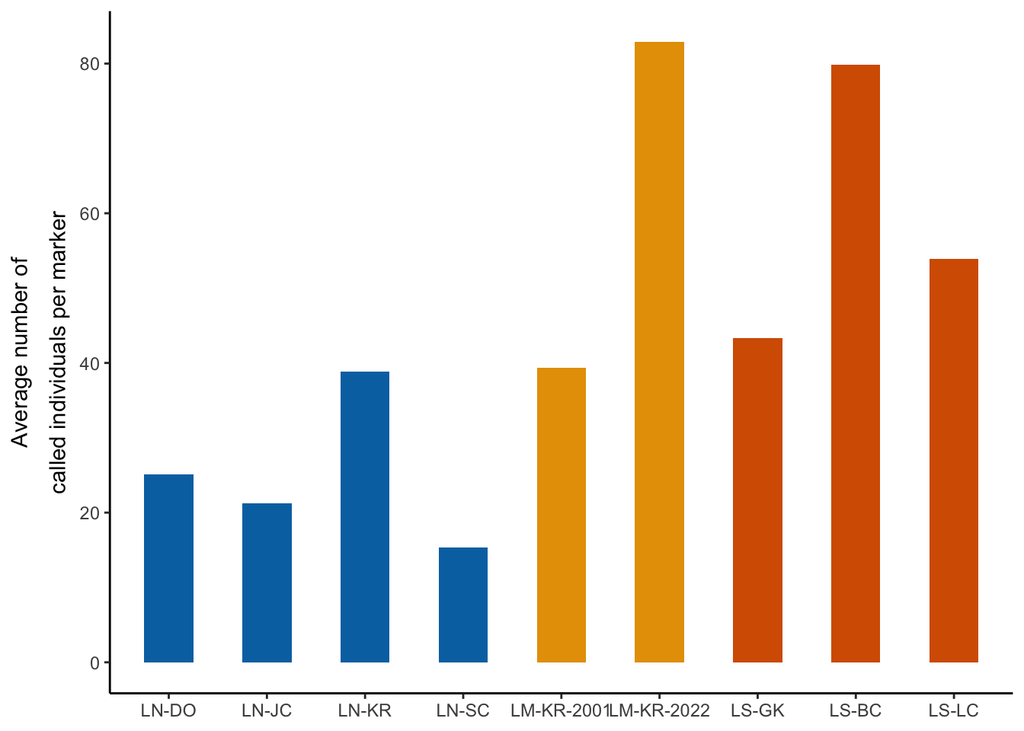

```r
p1 <- ggplot(my.gl.het) +
  geom_bar(aes(x=pop,y=nInd, fill=pop),stat="identity",width = 0.5) +
  theme_classic() +
  ylab(expression(atop("Average number of", paste("called individuals per marker")))) +
  scale_fill_oi(order = c(5,5,5,5,1,1,6,6,6)) +
  theme(axis.title.x = element_blank(),
        legend.position = "none")
p1
```

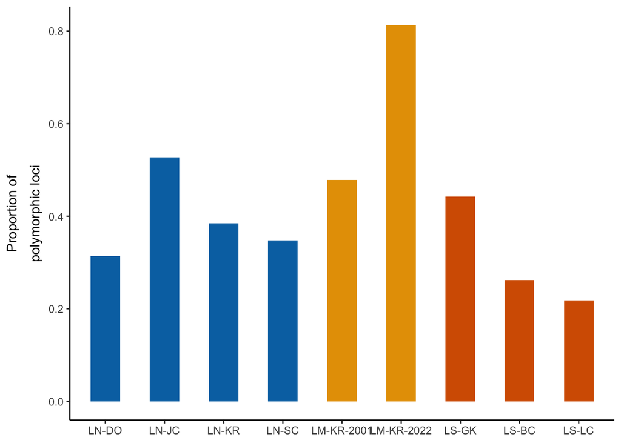

```r
p2 <- ggplot(my.gl.het) +
  geom_bar(aes(x=pop,y=polyLoc/nLoc, fill=pop),stat="identity",width = 0.5) +
  theme_classic() +
  ylab(expression(atop("Proportion of", paste("polymorphic loci")))) +
  scale_fill_oi(order = c(5,5,5,5,1,1,6,6,6)) +
  theme(axis.title.x = element_blank(),
        legend.position = "none")
p2
```

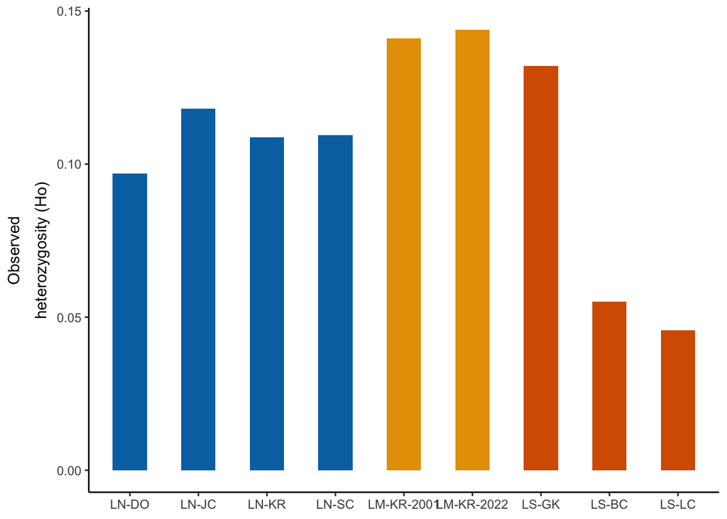

```r
p3 <- ggplot(my.gl.het) +
  geom_bar(aes(x=pop,y=Ho, fill=pop),stat="identity",width = 0.5) +
  theme_classic() +
  ylab(expression(atop("Observed", paste("heterozygosity (Ho)")))) +
  scale_fill_oi(order = c(5,5,5,5,1,1,6,6,6)) +
  theme(axis.title.x = element_blank(),
        legend.position = "none")
p3
```

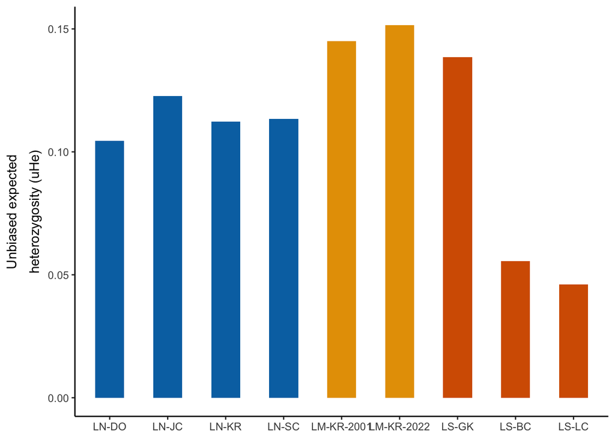

```r
p4 <- ggplot(my.gl.het) +
  geom_bar(aes(x=pop,y=uHe, fill=pop),stat="identity",width = 0.5) +
  theme_classic() +
  ylab(expression(atop("Unbiased expected", paste("heterozygosity (uHe)")))) +
  scale_fill_oi(order = c(5,5,5,5,1,1,6,6,6)) +
  theme(axis.title.x = element_blank(),
        legend.position = "none")
p4
```

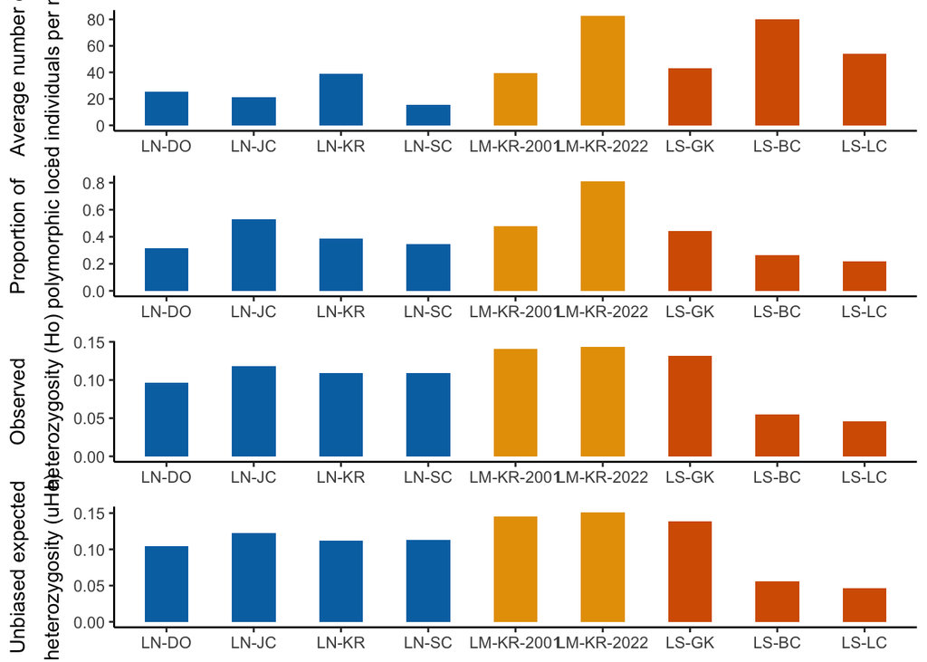

```r
p5 <- ggarrange(p1,p2,p3,p4, ncol = 1, align = "v")
p5
```

Save Supplementary Figure S16

```r
ggsave("../2_PopStructure/2_5_DiversityByPop.png",p5, device = "png",dpi = 300, height = 10)
```